# Exploratory Data Analysis: White Wine Quality

### Plot Analysis

Our final plots seek to take the conclusions of our linear model and make them more tangible.

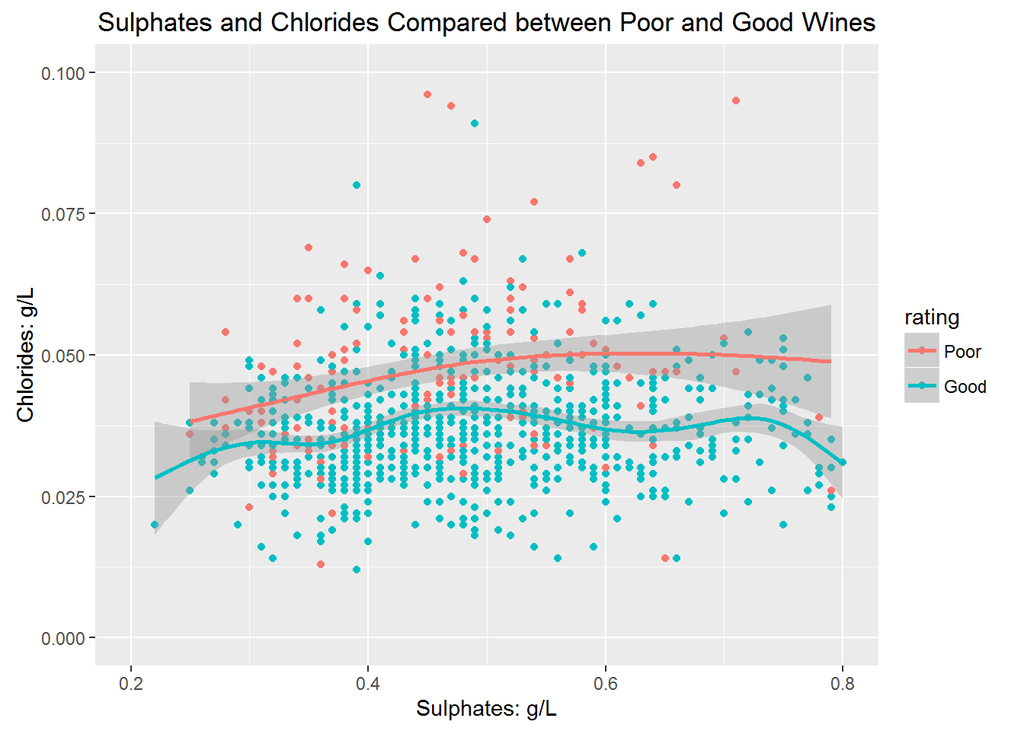

The first plot is a lesson in spurious correlation - I had created this plot before running the fourth model that includes every independent variable. The smoothers help us to see the difference in covariation between sulphates and chlorides between wines of Poor and Good quality, with the difference in means between the two ratings along the y-axis seeming pretty substantial. However, in light of the full model, chlorides failed to be a statistically significant predicting variable.

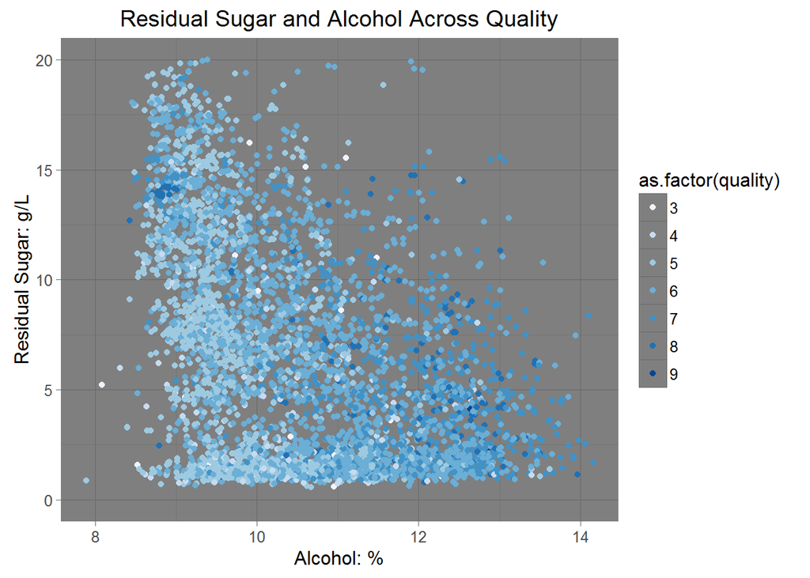

The second plot shows another side of the predictive quality of alcohol content. The whole of the graph shows a clear right-triangular shape - as we explored in our panel pairs, there is a solid negative correlation between residual sugar and alcohol content. This plot also shows some of the internal structure of the triangle by coloring points by their quality scores. Along the left, vertical edge of the triangle, most of the points are a light blue, indicating a low score in quality. However, as alcohol increases, tolerance for residual sugar seems to increase - even points high in the Y-axis become darker as we travel to the right on the X-axis.

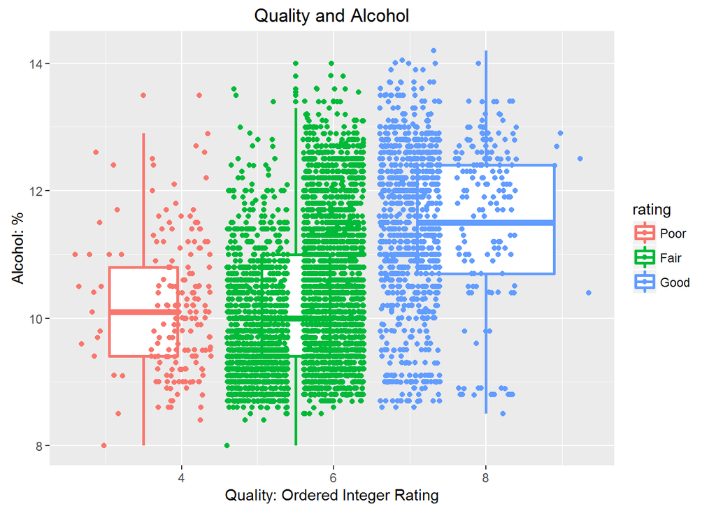

### Reflection

While this study has proven to be interesting in a number of ways, I would say that we have failed to create a strong predictive model for our dependent variable, quality. Even taking every measurement of every variable into consideration, our error term in the linear model still explains more than seventy percent of its total variation.

It must not be forgotten that the vast majority of this data set is scored either 5 or 6 in quality. Linear models benefit from having dependent variables that cover a wider array of values or have a finer degree of differentiation. In this case, more than two-thirds of our five thousand data points occupy the Fair category alone. The paucity of variation in our dependent variable likely contributes to the difficulty of fitting a good model.

What other variables may have aided us in understanding the quality of white wines? I may be speaking from ignorance, being something of a wine troglodyte, but it concerns me that we have no control for variation in scoring between different experts. It may be that wine experts actually have very tightly controlled and objective methods for rating white wines, but a categorical variable for which expert rated which wine is critical, even if it only confirms their expert rigor. Control over the most subjective part of our study would give me much greater faith in our results, even if our error term stayed just as high, because we could then faithfully chalk it up to the mysterious ‘je ne sais quoi’ of wine rather than questioning whether our quality ratings were influenced by personal preferences.